# Introducción a R

Author

Pablo Pardavila

## Bienvenido a Quarto

Para crear un documento Quarto, ve a File > New File > Quarto Document. Los documentos Quarto se pueden compilar como PDF o como HTML (este es un HTML).

Si abres el archivo `.qmd` en lugar del `.html`, verás al principio del documento unas líneas donde puedes escribir tu nombre, el título y otros ajustes. Eso se llama el **YAML**. He añadido `embed-resources: true`, que permite que otros vean tu archivo HTML aunque no esté en su ordenador. También he añadido una línea llamada `toc`, que añade una **t**abla de **c**ontenidos a tu archivo.

Este es un documento Quarto. Puedes añadir **negrita** y *cursiva* fácilmente. También puedes combinar lenguaje natural y código en un mismo lugar.

Para añadir código tienes que crear un bloque de código (chunk), ¡como el que aparece abajo! (Tienes instrucciones sobre cómo crear chunks y atajos de teclado en la presentación PowerPoint del seminario, disponible en el Aula Global).

```r
library(tidyverse) # Añadiendo el símbolo `#` dentro de un chunk, puedes escribir notas que no se ejecutarán.
library(readxl) # Aunque este paquete forma parte del tidyverse, es mejor cargarlo por separado. Esto nos permitirá leer archivos de Excel.

library(modelsummary) # Usaremos este paquete para crear tablas con buen formato. Si no lo tienes instalado, recuerda que primero debes instalarlo.
```

## Importar los datos

Para importar nuestros datos usaremos la función `read_excel`, ya que los datos vienen en formato `.xlsx`. Puedes escribir la ruta (la ubicación) de tu archivo de datos a mano, o puedes ir a File > Import Dataset > From Excel, buscar tu archivo y copiar en la esquina inferior derecha de la ventana emergente la ruta que aparece allí.

Con la flecha `<-` le estamos diciendo a R que asigne ese archivo a un **objeto**. Los objetos se guardan en nuestro entorno. Mantén este objeto intacto cuando hagas transformaciones de datos; así siempre sabrás cómo eran los datos originales. ¡Si cometes algún error grave durante el procesamiento de datos, siempre puedes volver a él!

```r
#Si tu archivo .qmd y tu carpeta data/ están en el mismo proyecto de RStudio, puedes escribir simplemente:
data <- read_excel("attacks2.xlsx")

# Si no lo están, tendrás que escribir toda la ruta del archivo. Por ejemplo:
#data <- read_excel("C:/Users/pablo/Desktop/PhD/introduccion_r/data/attacks2.xlsx")
```

## Explorar los datos

Para ver un resumen de nuestros datos:

```r
glimpse(data)
```

```
Rows: 30
Columns: 11
$ id          <dbl> 1, 2, 3, 4, 5, 6, 7, 8, 9, 10, 11, 12, 13, 14, 15, 16, 17,…
$ country     <chr> "Barbarics", "Lalaland", "Cooland", "Lalaland", "Lalaland"…
$ year        <dbl> 2025, 2025, 2025, 2025, 2025, 2025, 2025, 2025, 2025, 2025…
$ month       <dbl> 1, 1, 1, 1, 1, 1, 1, 1, 1, 1, 1, 1, 1, 1, 1, 1, 1, 1, 2, 2…
$ type        <chr> "bomb", "knife", "poison", "accident", "bomb", "knife", "p…
$ gdp         <dbl> 100, 150, 200, 150, 150, 150, 150, 200, 100, 200, 200, 200…
$ population  <dbl> 500, 350, 300, 350, 350, 350, 350, 300, 500, 300, 300, 300…
$ mountains   <dbl> 1000, 700, 700, 700, 700, 700, 700, 700, 1000, 700, 700, 7…
$ democracy   <dbl> 1, 8, 7, 8, 8, 8, 8, 7, 1, 7, 7, 7, 7, 7, 7, 7, 8, 8, 8, 8…
$ nkill       <dbl> 19, 1, 1, 3, 9, 1, 1, 2, 29, 4, 2, 6, 10, 4, 1, 1, 2, 3, 1…
$ temperature <dbl> 25, 20, 15, 20, 20, 20, 20, 15, 25, 15, 15, 15, 15, 15, 15…
```

```r
summary(data)
```

```
       id          country               year          month
 Min.   : 1.00   Length:30          Min.   :2025   Min.   :1.0
 1st Qu.: 8.25   Class :character   1st Qu.:2025   1st Qu.:1.0
 Median :15.50   Mode  :character   Median :2025   Median :1.0
 Mean   :15.50                      Mean   :2025   Mean   :1.4
 3rd Qu.:22.75                      3rd Qu.:2025   3rd Qu.:2.0
 Max.   :30.00                      Max.   :2025   Max.   :2.0
     type                gdp        population    mountains      democracy
 Length:30          Min.   :100   Min.   :300   Min.   : 700   Min.   :1.0
 Class :character   1st Qu.:100   1st Qu.:300   1st Qu.: 700   1st Qu.:1.0
 Mode  :character   Median :150   Median :350   Median : 700   Median :7.0
                    Mean   :145   Mean   :395   Mean   : 820   Mean   :4.9
                    3rd Qu.:200   3rd Qu.:500   3rd Qu.:1000   3rd Qu.:8.0
                    Max.   :200   Max.   :500   Max.   :1000   Max.   :8.0
     nkill         temperature
 Min.   : 1.000   Min.   :15.00
 1st Qu.: 1.000   1st Qu.:15.00
 Median : 2.500   Median :20.00
 Mean   : 4.733   Mean   :22.63
 3rd Qu.: 5.000   3rd Qu.:32.00
 Max.   :29.000   Max.   :32.00
```

```r
data |> count(country) # Para saber más sobre el operador pipe (|>), consulta las diapositivas del Lab de Datos.
```

```
# A tibble: 3 × 2
  country       n
  <chr>     <int>
1 Barbarics    12
2 Cooland       9
3 Lalaland      9
```

```r
# Para obtener una lista de países en nuestro conjunto de datos:
data |>
  pull(country) |>
  unique()
```

```
[1] "Barbarics" "Lalaland"  "Cooland"
```

```r
# Para hacer lo mismo en R base:
unique(data$country)
```

```
[1] "Barbarics" "Lalaland"  "Cooland"
```

## Gráficos de barras

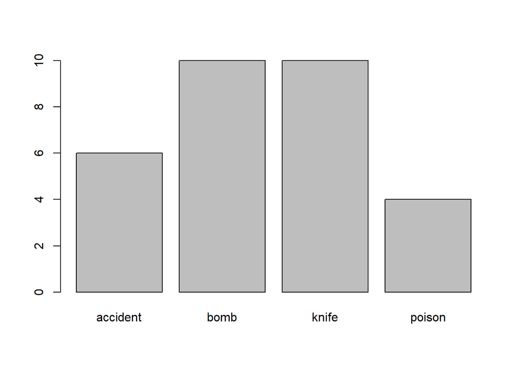

```r
# Si quiero contar observaciones por tipo:

# En R base
barplot(table(data$type))
```

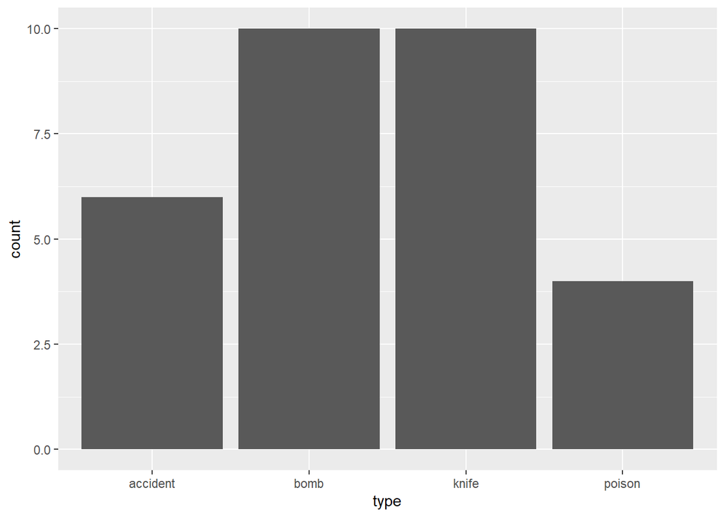

```r
# Con tidyverse (usando el paquete ggplot):
ggplot(data,
       aes(x = type)) +
  geom_bar()
```

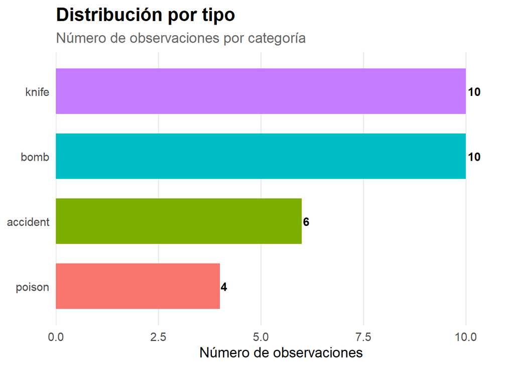

```r
# Con ggplot puedes hacer figuras muy elaboradas:

data |>
  count(type) |>
  mutate(type = fct_reorder(type, n)) |>
  ggplot(aes(x = type, y = n, fill = type)) +
  geom_col(width = 0.7, show.legend = FALSE) +
  geom_text(aes(label = n),
            hjust = -0.15,
            size = 4,
            fontface = "bold") +
  coord_flip() +
  scale_fill_manual(values = scales::hue_pal()(length(unique(data$type)))) +
  scale_y_continuous(expand = expansion(mult = c(0, 0.1))) +
  labs(
    title = "Distribución por tipo",
    subtitle = "Número de observaciones por categoría",
    x = NULL,
    y = "Número de observaciones"
  ) +
  theme_minimal(base_size = 14) +
  theme(
    plot.title = element_text(face = "bold", size = 18),
    plot.subtitle = element_text(color = "grey40"),
    panel.grid.major.y = element_blank(),
    panel.grid.minor = element_blank()
  )
```

## Gráficos de dispersión

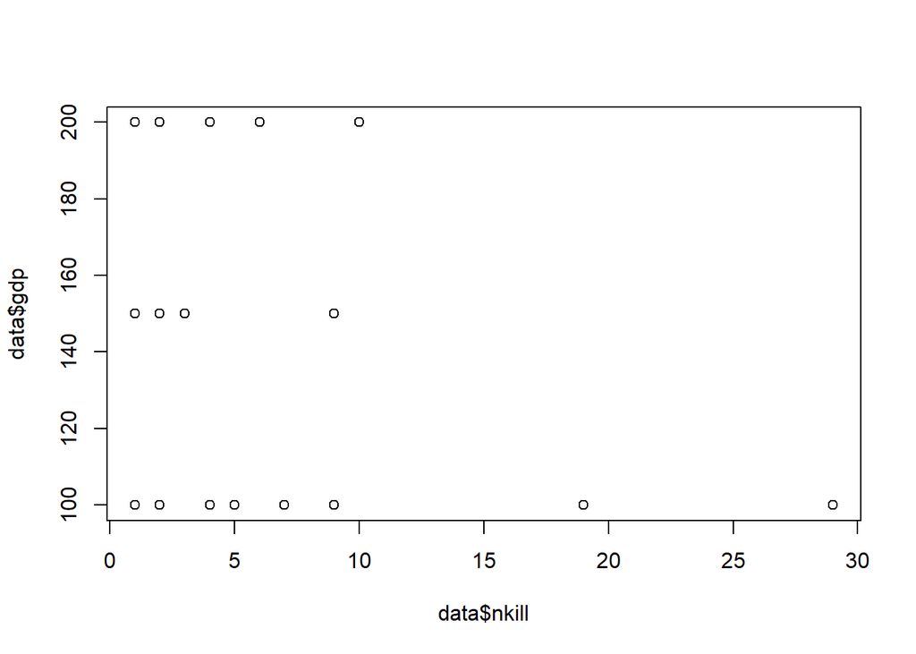

```r
# Para hacer gráficos de dispersión:

# En R base
plot(data$nkill, data$gdp)
```

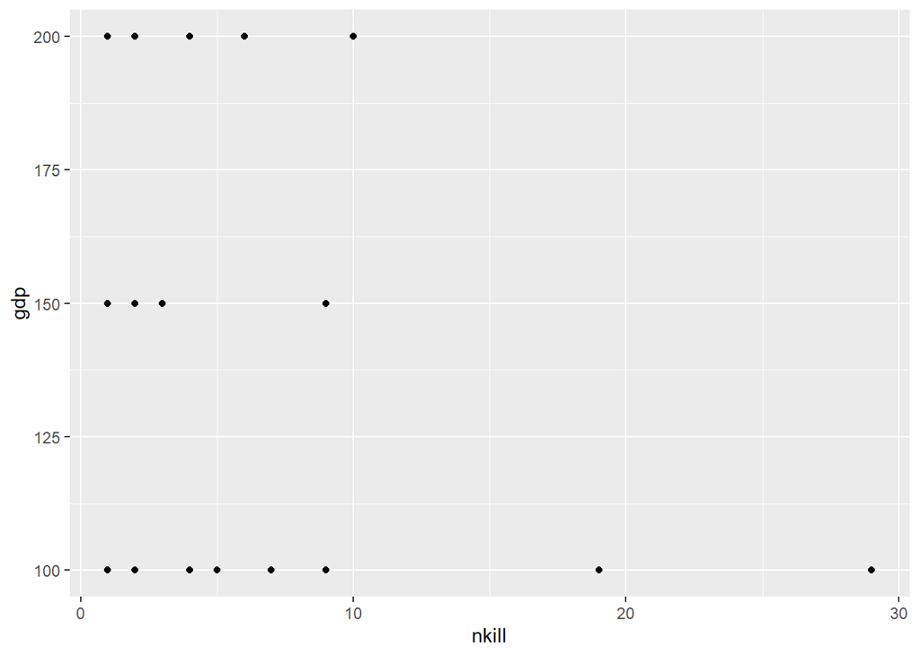

```r
# Con tidyverse
ggplot(data,
       aes(x = nkill, y = gdp)) +
  geom_point()
```

## Histograma

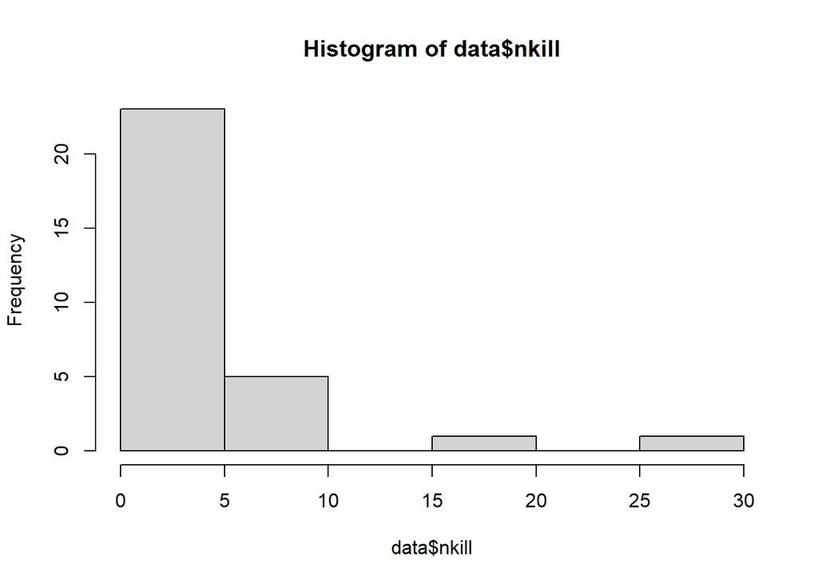

```r
# Histograma

# En R base

hist(data$nkill)
```

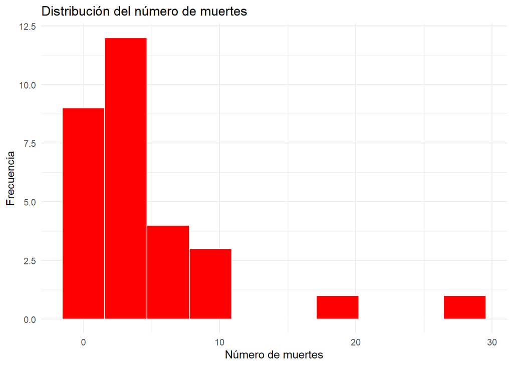

```r
# Con tidyverse

ggplot(data,
       aes(x = nkill)) +
  geom_histogram(bins = 10,
                 fill = "red",
                 color = "white") +
  labs(title = "Distribución del número de muertes",
       x = "Número de muertes",
       y = "Frecuencia") +
  theme_minimal()
```

## Una regresión OLS básica

```r
# OLS básico

ols <- lm(nkill ~ gdp + temperature + type + population + mountains + democracy,
            data = data)

summary(ols)
```

```
Call:
lm(formula = nkill ~ gdp + temperature + type + population +
    mountains + democracy, data = data)

Residuals:
    Min      1Q  Median      3Q     Max
-5.5065 -1.9808  0.3401  1.5109  7.1457

Coefficients: (2 not defined because of singularities)
             Estimate Std. Error t value Pr(>|t|)
(Intercept) -23.00401   17.84852  -1.289   0.2103
gdp           0.01891    0.05400   0.350   0.7294
temperature  -2.16195    0.32223  -6.709 7.63e-07 ***
typebomb      4.15036    2.05622   2.018   0.0554 .
typeknife    -1.57845    1.72519  -0.915   0.3697
typepoison   -2.20044    2.02406  -1.087   0.2882
population    0.18573    0.03619   5.132 3.36e-05 ***
mountains          NA         NA      NA       NA
democracy          NA         NA      NA       NA
---
Signif. codes:  0 '***' 0.001 '**' 0.01 '*' 0.05 '.' 0.1 ' ' 1

Residual standard error: 3.079 on 23 degrees of freedom
Multiple R-squared:  0.7907,    Adjusted R-squared:  0.7361
F-statistic: 14.48 on 6 and 23 DF,  p-value: 8.499e-07
```

## Tabla resumen del modelo

```r
modelsummary(ols,
             stars = TRUE,
             fmt = 2,
             title = "Determinantes de nkill (OLS)")
```

Determinantes de nkill (OLS)

|  | (1) |
| --- | --- |
| (Intercept) | -23.00 |
|  | (17.85) |
| gdp | 0.02 |
|  | (0.05) |
| temperature | -2.16*** |
|  | (0.32) |
| typebomb | 4.15+ |
|  | (2.06) |
| typeknife | -1.58 |
|  | (1.73) |
| typepoison | -2.20 |
|  | (2.02) |
| population | 0.19*** |
|  | (0.04) |
| Num.Obs. | 30 |
| R2 | 0.791 |
| R2 Adj. | 0.736 |
| AIC | 160.6 |
| BIC | 171.9 |
| Log.Lik. | -72.322 |
| RMSE | 2.70 |

+ p < 0.1, * p < 0.05, ** p < 0.01, *** p < 0.001

El paquete `modelsummary` también nos permite exportar tablas con buen formato a distintos formatos. Exportarlas a formato de texto plano (`.tex`) será útil cuando aprendamos a escribir en lenguaje *LaTeX*. Por defecto, el archivo `.tex` se guardará en la carpeta de tu proyecto.

```r
modelsummary(ols, # Fíjate en que este es el nombre que le dimos al objeto de nuestra regresión
             output = "olstable.tex", # Este será el nombre de nuestro archivo
             stars = TRUE, # Esto añade asteriscos de significación estadística
             title = "Determinantes de nkill (OLS)" # Esto le da un título a la tabla
             )
```